# Feyncalc

```
Print["The current Mathematica version is: ", $Version]
```

```
The current Mathematica version is:

>   14.1.0 for Linux x86 (64-bit) (July 16, 2024)
```

```
<< FeynCalc`FeynCalc`;
```

```
FeynCalc 10.1.0 (stable version). For help, use the online documentation,

>    visit the forum and have a look at the supplied examples.

>    The PDF-version of the manual can be downloaded here.
If you use FeynCalc in your research, please evaluate FeynCalcHowToCite[] to\

>   learn how to cite this software.
Please keep in mind that the proper academic attribution of our work is\

>   crucial to ensure the future development of this package!
```

```
FeynCalcHowToCite[]
```

```
 \[Bullet] V. Shtabovenko, R. Mertig and F. Orellana, arXiv:2312.14089.
 \[Bullet] V. Shtabovenko, R. Mertig and F. Orellana, Comput.Phys.Commun. 256\

>   (2020) 107478, arXiv:2001.04407.
 \[Bullet] V. Shtabovenko, R. Mertig and F. Orellana, Comput.Phys.Commun. 207\

>   (2016) 432-444, arXiv:1601.01167.
 \[Bullet] R. Mertig, M. Bo"hm, and A. Denner, Comput. Phys. Commun. 64\

>   (1991) 345-359.
```

# Scalar Products in 2-body Scattering

[figure not shown]

*Figure 1: 2-body scattering process*

## Maldelstam Variables

The Mandelstam variables are a set of three variables used in high-energy particle physics to describe the kinematics of scattering processes. They are defined in terms of the four-momenta of the particles involved in the scattering. The Mandelstam variables are denoted by $\hat s$, $\hat t$, and $\hat u$.

- $\hat s$ is the square of the total energy in the center-of-momentum frame, defined as: $$ \hat s = (p_1 + p_2)^2 = m_1^2 + m_2^2 + 2 p_1 \cdot p_2 $$
- $\hat t$ is the square of the momentum transfer, defined as: $$ \hat t = (p_1 - p_3)^2 = m_1^2 + m_3^2 - 2 p_1 \cdot p_3 $$
- $\hat u$ is the square of the other momentum transfer, defined as: $$ \hat u = (p_1 - p_4)^2 = m_1^2 + m_4^2 - 2 p_1 \cdot p_4 $$

## Simplification of Scalar Products using Mandelstam Variables

When evaluating a Feynman amplitude, one often finds scalar products of the external four-momenta. One can use the Mandelstam variables $(\hat s, \hat t, \hat u)$ to simplify these:

$$ \begin{aligned} & p_1 \cdot p_2 = \frac{\hat s - m_1^2 - m_2^2}{2} \\ & p_1 \cdot p_3 = \frac{m_1^2 + m_3^2 - \hat t }{2} \\ & p_1 \cdot p_4 = \frac{m_1^2 + m_4^2 - \hat u }{2} \end{aligned} $$ Where $m_i$ is the mass of the particle with corresponding momentum $p_i$.

## Anhilation/Conversion in center of mass frame

If the two incoming particles are identical, we can set $m_1 = m_2 = m_{\text{in}}$ and $\vec{p}_1 = -\vec{p}_2 = \vec{p}_{\text{in}}$, which gives us: $$ \begin{aligned} \hat s &= (p_1 + p_2)^2 = (p_1^0 + p_2^0)^2 - (\vec{p}_1 + \vec{p}_2)^2 \\&= (E_{1} + E_{1})^2 - (\vec{p}_{1} - \vec{p}_{1})^2 \\&= 4 E_{\text{1}}^2 \end{aligned} $$ We define the center of mass energy as $E_{\text{CM}} = 2 E_{\text{in}}$, so we have: $$ \hat s = E_{\text{CM}}^2 $$

Similarly if the two outgoing particles are identical, we can set $m_3 = m_4 = m_{\text{out}}$ and $\vec{p}_3 = -\vec{p}_4$, so $E_{1} = E_{2} = E_{\text{out}}=E_{\text{CM}}/2=E_{\text{in}}=E_{1}=E_{2}$, which gives us: $$ \begin{aligned} \hat t &= (p_1 - p_3)^2 = (p_1^0 - p_3^0)^2 - (\vec{p}_1 - \vec{p}_3)^2 \\&= (E_{1} - E_{3})^2 - (\vec{p}_{1} - \vec{p}_{3})^2 \\&= (E_{\text{in}} - E_{\text{out}})^2 - (\vec{p}_{\text{in}} - \vec{p}_{\text{out}})^2 \\&= (E_{\text{CM}}/2 - E_{\text{CM}}/2)^2 - (\vec{p}_{\text{in}} - \vec{p}_{\text{out}})^2 \\&= 0 - (\vec{p}_{\text{in}} - \vec{p}_{\text{out}})^2 \\&= -\vec{p}_{\text{in}}^2 - \vec{p}_{\text{out}}^2 + 2 \vec{p}_{\text{in}} \cdot \vec{p}_{\text{out}} \end{aligned} $$ We can change $\vec{p}_{\text{in}}^2 = E_{\text{in}}^2 - m_{\text{in}}^2$ and $\vec{p}_{\text{out}}^2 = E_{\text{out}}^2 - m_{\text{out}}^2$, so we have: $$ \begin{aligned} \hat t &= - E_{\text{in}}^2 - E_{\text{out}}^2 + m_{\text{in}}^2 + m_{\text{out}}^2 + 2 \sqrt{E_{\text{in}}^2 - m_{\text{in}}^2} \sqrt{E_{\text{out}}^2 - m_{\text{out}}^2} \cos \theta\\ \\&= m_{\text{in}}^2 + m_{\text{out}}^2 -\frac{1}{2} E_{\text{CM}}^2 + \frac{1}{2} \sqrt{E_{\text{CM}}^2 - 4 m_{\text{in}}^2} \sqrt{E_{\text{CM}}^2 - 4 m_{\text{out}}^2} \cos \theta \end{aligned} $$ Where $\theta$ is the angle between the incoming and outgoing particles, see Figure 2.

[figure not shown]

*Figure 2: ingoing and outgoing particles in the center of mass frame*

Similarly we can find $\hat u$: $$ \hat u = m_{\text{in}}^2 + m_{\text{out}}^2 -\frac{1}{2} E_{\text{CM}}^2 - \frac{1}{2} \sqrt{E_{\text{CM}}^2 - 4 m_{\text{in}}^2} \sqrt{E_{\text{CM}}^2 - 4 m_{\text{out}}^2} \cos \theta. $$

## Using the Pseudo-Rapidity

The pseudo-rapidity of a outgoing particle is defined as: $$ \eta = -\ln \left( \tan \frac{\theta}{2} \right) $$ with $\theta$ being the angle between the incoming axis and the outgoing particle, see Figure 2.

Then, we have $$ \tan \frac{\theta}{2} = e^{-\eta} $$ and using the identity: $$ \cos \theta = \frac{1 - \tan^2 \frac{\theta}{2}}{1 + \tan^2 \frac{\theta}{2}} = \frac{1 - e^{-2\eta}}{1 + e^{-2\eta}} = \frac{e^{\eta} - e^{-\eta}}{e^{\eta} + e^{-\eta}} = \tanh(\eta) $$ we can rewrite the Mandelstam variables as: $$ \begin{aligned} \hat s &= E_{\text{CM}}^2 \\ \hat t &= m_{\text{in}}^2 + m_{\text{out}}^2 -\frac{1}{2} E_{\text{CM}}^2 + \frac{1}{2} \sqrt{E_{\text{CM}}^2 - 4 m_{\text{in}}^2} \sqrt{E_{\text{CM}}^2 - 4 m_{\text{out}}^2} \tanh(\eta)\\ \hat u &= m_{\text{in}}^2 + m_{\text{out}}^2 -\frac{1}{2} E_{\text{CM}}^2 - \frac{1}{2} \sqrt{E_{\text{CM}}^2 - 4 m_{\text{in}}^2} \sqrt{E_{\text{CM}}^2 - 4 m_{\text{out}}^2} \tanh(\eta) \end{aligned} $$

# $b \bar b \to \tau^+\tau^-$

The bottom quark and the tau lepton have masses of $M_Q \approx 4.18$ GeV and $M_l \approx 1.78$ GeV, respectively. However, in the ultrarelativistic limit, we have center-of-mass energies of $E_{cm} \gg M_Q, M_l$, so we can neglect the masses of the particles and define

```
(* Masses *)

ml = Subscript[M, l]*0;
mq = Subscript[M, Q]*0;
```

```
(* p1 = momentum of incoming quark *)
(* p2 = momentum of incoming anti-quark *)
(* p3 = momentum of outgoing lepton *)
(* p4 = momentum of outgoing anti-lepton *)

m1 = mq;
m2 = mq;

m3 = ml;
m4 = ml;

p1 = Subscript["p", "b"];
p2 = Subscript["p", Overscript["b", "_"]];

p3 = Subscript["p", "l-"];
p4 = Subscript["p", "l+"];
```

```
energy = Subscript["E", "CM"];

CosTheta = Tanh[\[Eta]];

sMan = energy^2
tMan = m1^2 + m3^2 - (1/2)*energy^2 + (1/2)*Sqrt[energy^2 - 4*m1^2]*Sqrt[energy^2 - 4*m3^2]*CosTheta // Factor ;
uMan = m1^2 + m3^2 - (1/2)*energy^2 - (1/2)*Sqrt[energy^2 - 4*m1^2]*Sqrt[energy^2 - 4*m3^2]*CosTheta //Factor ;
```

```
SP[p1, p1] = m1^2;
SP[p1, p2] = (sMan - m1^2 - m2^2)/2;
SP[p1, p3] = (m1^2 + m3^2 - tMan)/2;
SP[p1, p4] = (m1^2 + m4^2 - uMan)/2;

SP[p2, p2] = m2^2;
SP[p2, p3] = (m2^2 + m3^2 - uMan)/2;
SP[p2, p4] = (m2^2 + m4^2 - tMan)/2;

SP[p3, p3] = m3^2;
SP[p3, p4] = (sMan - m3^2 - m4^2)/2;

SP[p4, p4] = m4^2;
```

Teh external legs of the Feynman diagram are given by the spinors, $u(p)$ and $\bar v(p)$ for each of the incoming particles, and $v(p)$ and $\bar u(p)$ for each of the outgoing particles:

```
PR = DiracMatrix[6];
PL = DiracMatrix[7];


b = SpinorU[p1, mq];
tau = SpinorUBar[p3, ml];

antiB = SpinorVBar[p2, mq];
antiTau = SpinorV[p4, ml];
```

# Scalar Leptoquark

The $\tilde S_1$ leptoquark is a scalar particle that couples to the right-handed down-type quarks and the right-handed leptons and transform in the $(3, 1, -4/3)$ representation of the Standard Model gauge group. $$ \mathcal{L}_{\tilde S_1} = \big(\mathcal{D}^\mu \tilde S_1\big)^\dagger \big(\mathcal{D}_\mu \tilde S_1\big) - m_{\tilde S_1}^2 \tilde S_1^\dagger \tilde S_1 + y_{R}^{ij} \bar {d^C}_{R}^{i} \tilde S_1 l_{R}^j + h.c. $$ **(¿ can we have couplings $Z^{ij} \bar {u^C}_{R}^{i} \tilde S_1^\dagger u_{R}^j$ also ? the QCD charges doesn't fit)** which has been implemented in feynrules ([arXiv: abs/1801.07641](https://arxiv.org/abs/1801.07641)) as:

```
(* The Lagrangian for the scalar leptoquark S1 *)
LS1tKin := Module[ {mu,c},
DC[S1tm43bar[c],mu] DC[S1tm43[c],mu] - MS1t^2 S1tm43bar[c] S1tm43[c]
];

LS1tYuk :=  Module[ {sp,i,j,cc},
 ExpandIndices[yRR[i,j] dRbar[sp,i,cc].CC[lR][sp,j] S1tm43[cc], FlavorExpand-> Generation]
];
```

The propagator for the leptoquark is given by: $$ \mathcal{P}_{\tilde S_1}(p) = \frac{-i}{p^2 - m_{\tilde S_1}^2 + i m_{\tilde S_1} \Gamma_{\tilde S_1}} $$ with the decay width given by: $$ \Gamma_{\tilde S_1} = \frac{m_{\tilde S_1}}{8 \pi} \left( \frac{1}{2} \sum_{i,j} |y_{R}^{ij}|^2 \right) $$ where ([arXiv: abs/1801.07641](https://arxiv.org/abs/1801.07641)) have implemented the decay width in feynrules as:

```
(* The decay width for the leptoquark S1 *)
WS1t == {
   ParameterType -> Internal,
   Value         -> (MS1t*(Abs[yRR[1,1]]^2 + Abs[yRR[1,2]]^2 + Abs[yRR[1,3]]^2
			 + Abs[yRR[2,1]]^2 + Abs[yRR[2,2]]^2 + Abs[yRR[2,3]]^2
                         + Abs[yRR[3,1]]^2 + Abs[yRR[3,2]]^2 + Abs[yRR[3,3]]^2))/(16*Pi)
}
```

So, assuming preferential couplings to the third generation, we have a vertex $b \tilde S_1^* \tau^-$ with coupling $i y_{R}^{33} P_L$ and $\bar{b} \tilde S_1\tau^+$ with coupling $i y_{R}^{33} P_R$ that feynrules implements as:

```
V_84 = Vertex(name = 'V_84',
              particles = [ P.ta__minus__, P.b, P.S1tm43__star__ ],
              color = [ 'Identity(2,3)' ],
              lorentz = [ L.FFS1 ],
              couplings = {(0,0):C.GC_69})

V_85 = Vertex(name = 'V_85',
              particles = [ P.ta__plus__, P.b__tilde__, P.S1tm43 ],
              color = [ 'Identity(2,3)' ],
              lorentz = [ L.FFS3 ],
              couplings = {(0,0):C.GC_69})
```

where the coupling C.GC_69 is given by:

```
GC_69 = Coupling(name = 'GC_69',
                 value = 'complex(0,1)*yRR3x3',
                 order = {'NP':1})
```

and the Lorentz structures are given by:

```
FFS1 = Lorentz(name = 'FFS1',
               spins = [ 2, 2, 1 ],
               structure = 'ProjM(2,1)')
FFS3 = Lorentz(name = 'FFS3',
               spins = [ 2, 2, 1 ],
               structure = 'ProjP(2,1)')
```

```
ms = Subscript[M, "S"];
ws = Subscript[\[CapitalGamma], "S"];

yR = Subscript[y, R];

sLQTildevertex = I *yR*PR;
sLQvertex =  I *yR*PL;

PropagatorS[p_] := -I/(ExpandScalarProduct[SP[p,p]] - ms^2 + I ms  ws )
```

## 'Unpolarized' Amplitude

So there, the 'unpolarized' amplitude for the process

[figure not shown]

*Figure 3: Feynman diagram for the process $b \bar b \to \tau^+ \tau^-$ mediated by a scalar leptoquark $\tilde S_1$*

```
(** Unpolarized Amplitude **)

line1 = b.sLQTildevertex.tau ;
line2 = antiB.sLQvertex.antiTau ;

Amplitude = line1 * line2 * PropagatorS[p1-p3] ;

AmplitudeSquared = ExpandAll[ Amplitude (ComplexConjugate[Amplitude]) // FermionSpinSum[#] & // DiracSimplify ] // Factor
```

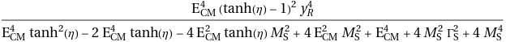

## Polarization of the $\tau$ lepton

The Polarization of the tau lepton is defined as: $$ P_\tau = \frac{|\mathcal{M}_R|^2 - |\mathcal{M}_L|^2}{|\mathcal{M}_R|^2 + |\mathcal{M}_L|^2} $$ where the polarized amplitudes for the $\tau^-$ lepton are given by:

```
(* tau Left Polarized Amplitude *)

leftPolarizedLine1 = b.sLQTildevertex.PL.tau ;
unpolarizedLine2 = antiB.sLQvertex.antiTau ;

MtauL = leftPolarizedLine1 * unpolarizedLine2 * PropagatorS[p1-p3] ;
MtauLSquared = ExpandAll[ MtauL (ComplexConjugate[MtauL]) // FermionSpinSum[#] & // DiracSimplify ] // Factor ;

(* tau Right Polarized Amplitude *)
rightPolarizedLine1 = b.sLQTildevertex.PR.tau ;
unpolarizedLine2 = antiB.sLQvertex.antiTau ;

MtauR = rightPolarizedLine1 * unpolarizedLine2 * PropagatorS[p1-p3] ;
MtauRSquared = ExpandAll[ MtauR (ComplexConjugate[MtauR]) // FermionSpinSum[#] & // DiracSimplify ] // Factor ;

(* tau polarization *)
Polarization = (MtauRSquared - MtauLSquared) / (MtauRSquared + MtauLSquared) // Factor ;

Print["Polarization: ", Polarization]
```

```
Polarization: 1
```

and the polarized amplitudes for the $\tau^+$ lepton are given by:

```
(* antitau Left Polarized Amplitude *)
unpolarizedLine1 = b.sLQTildevertex.tau ;
leftPolarizedLine2 = antiB.sLQvertex.PL.antiTau ;
MAntiTauL = unpolarizedLine1 * leftPolarizedLine2 * PropagatorS[p1-p3] ;
MAntiTauLSquared = ExpandAll[ MAntiTauL (ComplexConjugate[MAntiTauL]) // FermionSpinSum[#] & // DiracSimplify ] // Factor ;

(* antitau Right Polarized Amplitude *)
unpolarizedLine1 = b.sLQTildevertex.tau ;
rightPolarizedLine2 = antiB.sLQvertex.PR.antiTau ;
MAntiTauR = unpolarizedLine1 * rightPolarizedLine2 * PropagatorS[p1-p3] ;
MAntiTauRSquared = ExpandAll[ MAntiTauR (ComplexConjugate[MAntiTauR]) // FermionSpinSum[#] & // DiracSimplify ] // Factor ;

(* antitau polarization *)
MAntiTauPolarization = (MAntiTauRSquared - MAntiTauLSquared) / (MAntiTauRSquared + MAntiTauLSquared) // Factor ;
Print["Antitau Polarization: ", MAntiTauPolarization]
```

```
Antitau Polarization: -1
```

In madgraph, with $Y_R^{33}= 1$, and a leptoquark mass of $M_{\tilde S_1} = 650 \text{GeV}$, We have evaluated the cross-section for different processes:

```
import model <path_to_model>
generate p p > ta+ ta-{R} QED=0
```

we got the output:

```
- Current estimate of cross-section: 0.019482 +- 0.00042827
    P1_qq_taptamR
    P1_qbx_taptamR
    P1_bbx_taptamR
```

```
import model <path_to_model>
generate p p > ta+ ta-{L} QED=0
```

we got the output:

```
- Current estimate of cross-section: 2.4629e-06 +- 4.6684e-08
    P1_qq_taptamL
    P1_qbx_taptamL
    P1_bbx_taptamL
```

```
import model <path_to_model>
generate p p > ta+{R} ta- QED=0
```

we got the output:

```
- Current estimate of cross-section: 2.4629e-06 +- 4.6684e-08
    P1_qq_tapRtam
    P1_qbx_tapRtam
    P1_bbx_tapRtam
```

```
import model <path_to_model>
generate p p > ta+{L} ta- QED=0
```

we got the output:

```
- Current estimate of cross-section: 0.019482 +- 0.00042827
    P1_qq_tapLtam
    P1_qbx_tapLtam
    P1_bbx_tapLtam
```

# Vectorial Leptoquark

We shall restrict ourselves to a simplified non-renormalizable lagrangian, understood to be embedded into a more complete model. The SM is thus extended by adding the following terms featuring the $U_1$ leptoquark: $$ \begin{aligned} \mathcal{L}_{U_1}&=&-\frac{1}{2}U^\dagger_{\mu\nu}U^{\mu\nu}+M_U^2\, U_{1\mu}^\dagger U_1^\mu -ig_s\,U_{1\mu}^\dagger\, T^a\, U_{1\nu}\, G^{a\mu\nu}\!\!-i\frac{2}{3}g'\,U^\dagger_{1\mu}U_{1\nu}B^{\mu\nu} +\frac{g_U}{\sqrt 2}[U_{1\mu}(\bar Q_3\,\gamma^\mu L_3+\beta_L^{s\tau}\,\bar Q_2\,\gamma^\mu L_3 +\beta_{R}\,\bar b_{R}\,\gamma^\mu \tau_{R}) +{\rm h.c.}] \end{aligned}d $$ where $U_{1\mu}$ is the vector leptoquark field, $M_U$ is its mass, $g_s$ is the strong coupling constant, $g'$ is the hypercharge coupling constant, and $g_U$ is the coupling of the leptoquark to the quarks and leptons. The term $T^a$ is the generator of the SU(3) color group, and $B^{\mu\nu}$ is the field strength tensor for hypercharge. The term $\beta_L^{s\tau}$ is a parameter that determines the strength of the coupling between the leptoquark and the left-handed quarks and leptons.

```
V_142 = Vertex(name = 'V_142',
               particles = [ P.b__tilde__, P.ta__minus__, P.VLQ ],
               color = [ 'Identity(1,3)' ],
               lorentz = [ L.FFV2, L.FFV3 ],
               couplings = {(0,0):C.GC_18,(0,1):C.GC_19})
V_152 = Vertex(name = 'V_152',
               particles = [ P.ta__plus__, P.b, P.VLQ__tilde__ ],
               color = [ 'Identity(2,3)' ],
               lorentz = [ L.FFV2, L.FFV3 ],
               couplings = {(0,0):C.GC_18,(0,1):C.GC_19})
```

with the couplings given by:

```
GC_18 = Coupling(name = 'GC_18',
                 value = '(betaL3x3*complex(0,1)*gU)/cmath.sqrt(2)',
                 order = {'NP':1})

GC_19 = Coupling(name = 'GC_19',
                 value = '(betaRd3x3*complex(0,1)*gU)/cmath.sqrt(2)',
                 order = {'NP':1})
```

and the Lorentz structures are given by:

```
FFV2 = Lorentz(name = 'FFV2',
               spins = [ 2, 2, 3 ],
               structure = 'Gamma(3,2,-1)*ProjM(-1,1)')

FFV3 = Lorentz(name = 'FFV3',
               spins = [ 2, 2, 3 ],
               structure = 'Gamma(3,2,-1)*ProjP(-1,1)')
```

[output not shown]

## 'Unpolarized' Amplitude

The amplitude for the process $b \bar b \to \tau^+ \tau^-$ mediated by a vector leptoquark $U_1$ is given by:

```
unpolarizedVectorialLine1[mm_] = b.vLQvertex[mm].tau ;
unpolarizedVectorialLine2[mm_] = antiB.vLQvertex[mm].antiTau ;

MVectorial = Contract[unpolarizedVectorialLine1[\[Mu]].PropagatorV[p1-p3, \[Mu] , \[Nu]]].unpolarizedVectorialLine2[\[Nu]] // DiracSimplify // Factor ;

ExpandAll[ MVectorial (ComplexConjugate[MVectorial]) // FermionSpinSum[#] & // DiracSimplify ]// Factor // Simplify
```

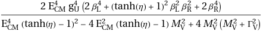

## Polarization of the $\tau$ lepton

```
leftPolarizedVectorialLine1[mm_] = b.vLQvertex[mm].PL.tau ;
unpolarizedVectorialLine2[mm_] = antiB.vLQvertex[mm].antiTau ;

MVectorialL = Contract[leftPolarizedVectorialLine1[\[Mu]].PropagatorV[p1-p3, \[Mu] , \[Nu]]].unpolarizedVectorialLine2[\[Nu]] // DiracSimplify // Factor ;
MVectorialLSquared = ExpandAll[ MVectorialL (ComplexConjugate[MVectorialL]) // FermionSpinSum[#] & // DiracSimplify ] // Factor

rightPolarizedVectorialLine1[mm_] = b.vLQvertex[mm].PR.tau ;
unpolarizedVectorialLine2[mm_] = antiB.vLQvertex[mm].antiTau ;

MVectorialR = Contract[rightPolarizedVectorialLine1[\[Mu]].PropagatorV[p1-p3, \[Mu] , \[Nu]]].unpolarizedVectorialLine2[\[Nu]] // DiracSimplify // Factor ;
MVectorialRSquared = ExpandAll[ MVectorialR (ComplexConjugate[MVectorialR]) // FermionSpinSum[#] & // DiracSimplify ] // Factor

(* tau polarization *)
MVectorialPolarization = (MVectorialRSquared - MVectorialLSquared) / (MVectorialRSquared + MVectorialLSquared) // Factor ;
MVectorialPolarization
```

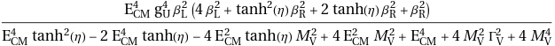

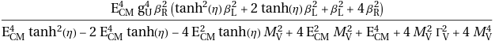

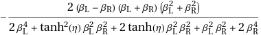

[output not shown]

[figure not shown]

Since the quark and antiquark are not comming from a predetermined beam, we must to make the avergage over $\eta$ and $-\eta$ to get the cross-section.

Tau Polarization will be given by:

[output not shown]

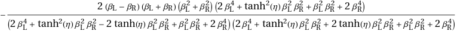

[figure not shown]

# Neutral Vector

$$ \mathcal{L}_{Z^{\prime}}= -\frac{1}{4} Z_{\mu \nu}^{\prime} Z^{\prime \mu \nu}+\frac{1}{2} M_{Z^{\prime}}^2 Z_\mu^{\prime} Z^{\prime \mu} + \frac{g_{Z^{\prime}}}{2 \sqrt{6}} Z^{\prime \mu} (\zeta_q \bar{Q}_3 \gamma_\mu Q_3 +\zeta_t \bar{t}_R \gamma_\mu t_R +\zeta_b \bar{b}_R \gamma_\mu b_R-3 \zeta_{\ell} \bar{L}_3 \gamma_\mu L_3-3 \zeta_\tau \bar{\tau}_R \gamma_\mu \tau_R) $$

The vertex $Z' b \bar b$ is $i \frac{g_{Z^{\prime}}}{2 \sqrt{6}} \gamma_\mu (\zeta_q \gamma^\mu P_L + \zeta_b \gamma^\mu P_R)$, and the vertex $Z' \tau^+ \tau^-$ is $-i \frac{3 g_{Z^{\prime}}}{2 \sqrt{6}} \gamma_\mu (\zeta_{\ell} \gamma^\mu P_L \zeta_\tau \gamma^\mu P_R)$, so we have:

[output not shown]

## 'Unpolarized' Amplitude

```
unpolarizedBottomLine1[mm_] = antiB.zLQvertexb[mm].b ;
unpolarizedTauLine2[mm_] = antiTau.zLQvertextau[mm].tau ;

MZp = Contract[unpolarizedBottomLine1[\[Mu]].PropagatorV[p1+p2, \[Mu] , \[Nu]]].unpolarizedTauLine2[\[Nu]] // DiracSimplify // Factor ;
MZpSquared = ExpandAll[ MZp (ComplexConjugate[MZp]) // FermionSpinSum[#] & // DiracSimplify ] // Factor
```

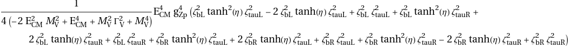

## Polarization of the $\tau$ lepton

```
unpolarizedBottomLine1[mm_] = b.zLQvertexb[mm].tau ;
leftPolarizedTauLine2[mm_] = antiTau.zLQvertextau[mm].PL.tau ;

MZpL = Contract[unpolarizedBottomLine1[\[Mu]].PropagatorV[p1+p2, \[Mu] , \[Nu]]].leftPolarizedTauLine2[\[Nu]] // DiracSimplify // Factor ;
MZpLSquared = ExpandAll[ MZpL (ComplexConjugate[MZpL]) // FermionSpinSum[#] & // DiracSimplify ] // Factor

rightPolarizedTauLine2[mm_] = antiTau.zLQvertextau[mm].PR.tau ;
MZpR = Contract[unpolarizedBottomLine1[\[Mu]].PropagatorV[p1+p2, \[Mu] , \[Nu]]].rightPolarizedTauLine2[\[Nu]] // DiracSimplify // Factor ;
MZpRSquared = ExpandAll[ MZpR (ComplexConjugate[MZpR]) // FermionSpinSum[#] & // DiracSimplify ] // Factor

(* tau polarization *)
MZpPolarization = (MZpRSquared - MZpLSquared) / (MZpRSquared + MZpLSquared) // Factor ;
MZpPolarization
```

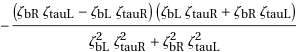

# Neutral Scalar

It will be zero, i don't want to do all the math for this, but it will be zero.